# Notebook - Competition - Meilleur Data Scientist de France

*This notebook is about my participation to the data science competition: ['Le Meilleur Data Scientist de France'](https://www.datascience.net/fr/challenge/25/details). This goal of this competition is to construct a predictive model to estimates the prices of medication boxes.*

[figure not shown]

## Summary

0. Exploratory Analysis

> 0.1 Import DataSet

> 0.2. Quick Look of the dataset

> 0.3. List the different type of features

> 0.4. Descriptive Analysis

1. Data Cleaning

> 1.1. Duplicated Rows

> 1.2. Duplicated Rows Bis (without interest variable)

> 1.3. NaN Values

2. Single Model

> 2.1. Cross-Validation

> 2.2. Single Model

> 2.3. Performance Metrics

> 2.4. Single Model Function

3. Features Engineering

> 3.1. Transformation of 'prix'

> 3.2. Date variables

> 3.3. Categorical Features

> 3.3. Treating Text Features

> 3.4. The Parse Method

4. Diverse Model Optimisation

> 4.1. Gradient Boosting

> 4.2. Random Forest

> 4.3. Extra Trees

> 4.4. Adaboost

> 4.5. Ridge Regression

> 4.6. Elastic Net

> 4.7. Lasso Regression

> 4.8. Support Vectors Machine

5. Stacking and Blending

> 5.1. Stacking by mean aggregation

> 5.2. Stacking by Linear Regression

## Notebook

Importation of classical libraries

```python
import pandas as pd
import numpy as np
import seaborn as sns
import matplotlib.pyplot as plt

%matplotlib inline
```

### 0. Exploratory Analysis

#### 0.1 Import the data

```python
train = pd.read_csv('Data/boites_medicaments_train.csv',encoding='utf8',sep=';')
test = pd.read_csv('Data/boites_medicaments_test.csv',encoding='utf8', sep=';')
```

#### 0.2 Quick look of the dataset

```python
train.head(3)
```

|  | libelle | libelle_plaquette | libelle_ampoule | libelle_flacon | libelle_tube | libelle_stylo | libelle_seringue | libelle_pilulier | libelle_sachet | libelle_comprime | ... | tx rembours | forme pharma | voies admin | statut admin | date declar annee | date amm annee | type proc | titulaires | substances | prix |
| --- | --- | --- | --- | --- | --- | --- | --- | --- | --- | --- | --- | --- | --- | --- | --- | --- | --- | --- | --- | --- | --- |
| 0 | 3 plaquette(s) thermoformée(s) PVC-Aluminium d... | 1 | 0 | 0 | 0 | 0 | 0 | 0 | 0 | 1 | ... | 65% | comprimé pelliculé | orale | Autorisation active | 2014 | 2014 | Procédure décentralisée | MAJORELLE LUXEMBOURG SOPARFI (LUXEMBOURG) | DÉSOGESTREL | 2.83 |
| 1 | plaquette(s) thermoformée(s) aluminium de 28 c... | 1 | 0 | 0 | 0 | 0 | 0 | 0 | 0 | 1 | ... | 65% | comprimé à croquer | orale | Autorisation active | 2013 | 2009 | Procédure de reconnaissance mutuelle | TEVA SANTE | MONTÉLUKAST ACIDE, MONTÉLUKAST SODIQUE | 14.30 |
| 2 | plaquette(s) thermoformée(s) PVC-aluminium de ... | 1 | 0 | 0 | 0 | 0 | 0 | 0 | 0 | 0 | ... | 65% | gélule à libération prolongée | orale | Autorisation active | 2000 | 1996 | Procédure nationale | MYLAN SAS | CHLORHYDRATE DE DILTIAZEM | 5.66 |

3 rows × 41 columns

```python
test.head(3)
```

|  | id | libelle | libelle_plaquette | libelle_ampoule | libelle_flacon | libelle_tube | libelle_stylo | libelle_seringue | libelle_pilulier | libelle_sachet | ... | agrement col | tx rembours | forme pharma | voies admin | statut admin | date declar annee | date amm annee | type proc | titulaires | substances |
| --- | --- | --- | --- | --- | --- | --- | --- | --- | --- | --- | --- | --- | --- | --- | --- | --- | --- | --- | --- | --- | --- |
| 0 | 1 | plaquette(s) thermoformée(s) polyamide alumini... | 1 | 0 | 0 | 0 | 0 | 0 | 0 | 0 | ... | non | 65% | comprimé gastro-résistant(e) | orale | Autorisation active | 2013 | 2008 | Procédure de reconnaissance mutuelle | TEVA SANTE | PANTOPRAZOLE SODIQUE SESQUIHYDRATÉ, PANTOPRAZOLE |
| 1 | 2 | plaquette(s) thermoformée(s) PVC PVDC aluminiu... | 1 | 0 | 0 | 0 | 0 | 0 | 0 | 0 | ... | non | 30% | capsule | vaginale | Autorisation active | 2012 | 1997 | Procédure nationale | INNOTECH INTERNATIONAL | NYSTATINE, SULFATE DE POLYMYXINE B, SULFATE DE... |
| 2 | 3 | plaquette(s) thermoformée(s) PVC-Aluminium de ... | 1 | 0 | 0 | 0 | 0 | 0 | 0 | 0 | ... | non | 65% | comprimé | orale | Autorisation abrogée | 2013 | 2006 | Procédure nationale | ACTAVIS FRANCE | PRAVASTATINE SODIQUE |

3 rows × 41 columns

We look the shape of the data

```python
y_var = [value for value in set(train.columns.values) - set(test.columns.values)]

print "Training set has {} samples and {} variables.".format(*train.shape)
print "Test set has {} samples and {} variables.".format(*test.shape)
print "The variable of interest is : '{}'.".format(*y_var)
```

```
Training set has 8564 samples and 41 variables.
Test set has 3671 samples and 41 variables.
The variable of interest is : 'prix'.
```

#### 0.3 List the different type of features

the idea is studying the different type of each variables. Constructing this kind of architecture allows to test different combinations in the feature engineering part.

```python
train.columns.values
```

```
array([u'libelle', u'libelle_plaquette', u'libelle_ampoule',
       u'libelle_flacon', u'libelle_tube', u'libelle_stylo',
       u'libelle_seringue', u'libelle_pilulier', u'libelle_sachet',
       u'libelle_comprime', u'libelle_gelule', u'libelle_film',
       u'libelle_poche', u'libelle_capsule', u'nb_plaquette',
       u'nb_ampoule', u'nb_flacon', u'nb_tube', u'nb_stylo',
       u'nb_seringue', u'nb_pilulier', u'nb_sachet', u'nb_comprime',
       u'nb_gelule', u'nb_film', u'nb_poche', u'nb_capsule', u'nb_ml',
       u'statut', u'etat commerc', u'agrement col', u'tx rembours',
       u'forme pharma', u'voies admin', u'statut admin',
       u'date declar annee', u'date amm annee', u'type proc',
       u'titulaires', u'substances', u'prix'], dtype=object)
```

```python
#Interest variable
y_var = ['prix']

# features numériques
feat_num = ['libelle_plaquette', 'libelle_ampoule', 'libelle_flacon',
            'libelle_tube', 'libelle_stylo', 'libelle_seringue',
            'libelle_pilulier', 'libelle_sachet', 'libelle_comprime',
            'libelle_gelule', 'libelle_film', 'libelle_poche',
            'libelle_capsule'] + ['nb_plaquette', 'nb_ampoule',
            'nb_flacon', 'nb_tube', 'nb_stylo', 'nb_seringue',
            'nb_pilulier', 'nb_sachet', 'nb_comprime', 'nb_gelule',
            'nb_film', 'nb_poche', 'nb_capsule', 'nb_ml']

# features date
feat_dates = ['date declar annee', 'date amm annee']

# features catégorielles
feat_cat = ['statut', 'etat commerc', 'agrement col', 'tx rembours',
          'voies admin', 'statut admin', 'type proc']

# features texte
feat_text = ['libelle', 'titulaires', 'substances', 'forme pharma']


# All features vector
feat_all = feat_num + feat_dates + feat_cat + feat_text
```

#### 0.4 Data Descriptive Analysis

##### 0.4.1. The interest variable: the price

First, we choose to look the distribition of the price. The distribution of the price is very unbalanced: we have a lot of price between 0 and 100. The problem with that will be that the supervized model learn badly. One way to tackle this problem is to transform this variable to a more 'normal' distribution. To do that we can use a log-transformation we verify if it is better in the next part.

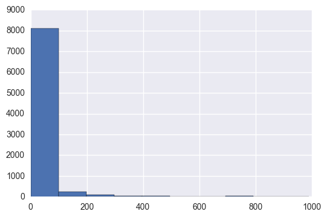

```python
train['prix'].hist()
```

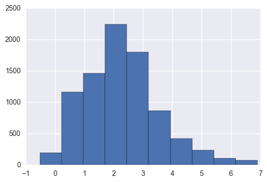

```python
train['logprix'] = train['prix'].apply(np.log)
train['logprix'].hist()
```

##### 0.4.2. The impact of 'tx rembours'

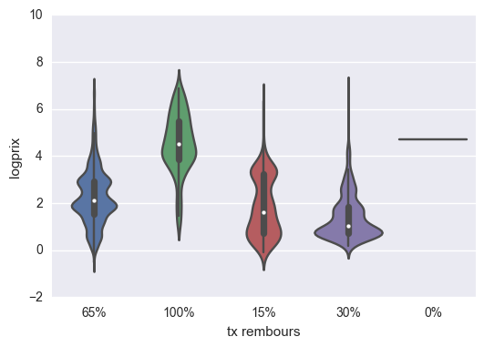

```python
sns.violinplot(y="logprix", x="tx rembours", data=train)
```

##### 0.4.3. The influence of the statut on the price

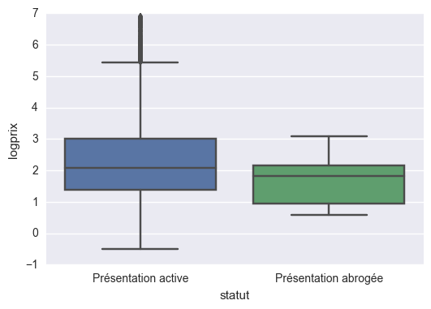

```python
sns.boxplot(y="logprix", x="statut", data=train)
```

##### 0.4.4. The distribution and the difference between 'AMM date' and 'declar date'

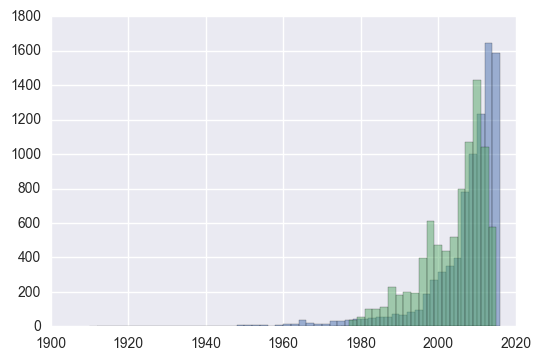

```python
bins_declar = (max(train['date declar annee'])- min(train['date declar annee']))/2
bins_amm = (max(train['date amm annee'])- min(train['date amm annee']))/2


train['date declar annee'].hist(bins=bins_declar, alpha=0.5)
train['date amm annee'].hist(bins=bins_amm, alpha=0.5)
```

```python
train['data_diff_declar_amm'] = train['date declar annee'] - train['date amm annee']
```

### 1. Data Cleaning

From this part, we work on the data. So, we choose to copy the two dataset to keep the original dataset unchanged.

```python
train_set = train.copy()
test_set = test.copy()
```

#### 1.1. Drop duplicates rows

Duplicates variables are not good to train a model because one individual is over represented. So,

- We check if it exists duplicates rows in the training set
- We suppress duplicates if it is necessary

```python
nb_duplicated = sum(train_set.duplicated())
print 'In the training set we found {} duplicated rows.' .format(nb_duplicated)
```

```
In the training set we found 376 duplicated rows.
```

```python
nb_duplicated = sum(test_set.duplicated())
print 'In the test set we found {} duplicated rows.' .format(nb_duplicated)
```

```
In the test set we found 0 duplicated rows.
```

We choose to suppress these rows.

```python
train_set.drop_duplicates(keep='first',inplace=True)
print 'After supressing duplicated values, the training set contains {} rows ({} previously)'.format(train_set.shape[0],train.shape[0])
```

```
After supressing duplicated values, the training set contains 8188 rows (8564 previously)
```

#### 1.2. Drop duplicates rows bis (without interest variable)

Note that in some cases there exists duplicated values for features but not for the interest variable. It seems important to verify this.

```python
nb_duplicated = sum(train_set[feat_all].duplicated())
print 'In the dataset we found {} duplicated rows.' .format(nb_duplicated)
```

```
In the dataset we found 691 duplicated rows.
```

How this values are the same and what is the difference in terms of prices?

```python
train_set[train_set[feat_all].duplicated(keep=False)==True].sort_values(by='libelle').head(4)
```

|  | libelle | libelle_plaquette | libelle_ampoule | libelle_flacon | libelle_tube | libelle_stylo | libelle_seringue | libelle_pilulier | libelle_sachet | libelle_comprime | ... | voies admin | statut admin | date declar annee | date amm annee | type proc | titulaires | substances | prix | logprix | data_diff_declar_amm |
| --- | --- | --- | --- | --- | --- | --- | --- | --- | --- | --- | --- | --- | --- | --- | --- | --- | --- | --- | --- | --- | --- |
| 3944 | 1 cartouche(s) bicompartimentée(s) en verre da... | 0 | 0 | 0 | 0 | 1 | 0 | 0 | 0 | 0 | ... | sous-cutanée | Autorisation active | 2002 | 2002 | Procédure centralisée | MERCK SHARP & DOHME (GRANDE BRETAGNE) | PEGINTERFÉRON ALFA-2B | 93.44 | 4.537320 | 0 |
| 3692 | 1 cartouche(s) bicompartimentée(s) en verre da... | 0 | 0 | 0 | 0 | 1 | 0 | 0 | 0 | 0 | ... | sous-cutanée | Autorisation active | 2002 | 2002 | Procédure centralisée | MERCK SHARP & DOHME (GRANDE BRETAGNE) | PEGINTERFÉRON ALFA-2B | 271.34 | 5.603373 | 0 |
| 4347 | 1 cartouche(s) bicompartimentée(s) en verre da... | 0 | 0 | 0 | 0 | 1 | 0 | 0 | 0 | 0 | ... | sous-cutanée | Autorisation active | 2002 | 2002 | Procédure centralisée | MERCK SHARP & DOHME (GRANDE BRETAGNE) | PEGINTERFÉRON ALFA-2B | 183.33 | 5.211288 | 0 |
| 5632 | 1 cartouche(s) bicompartimentée(s) en verre da... | 0 | 0 | 0 | 0 | 1 | 0 | 0 | 0 | 0 | ... | sous-cutanée | Autorisation active | 2002 | 2002 | Procédure centralisée | MERCK SHARP & DOHME (GRANDE BRETAGNE) | PEGINTERFÉRON ALFA-2B | 147.42 | 4.993286 | 0 |

4 rows × 43 columns

If we look the prices, we can remark we have a lot of difference between them. We have no information about the update of the data. So, we think one solution is to aggregate the data to choose the mean.

```python
nb_rows_before = train_set.shape[0]

train_set_1 = train_set[train_set[feat_all].duplicated(keep=False)==False]

duplicated_features = train_set[train_set[feat_all].duplicated(keep=False)==True]
agg_duplicated = duplicated_features.groupby(by=feat_all).mean()
agg_duplicated = agg_duplicated.reset_index()

train_set = train_set_1.append(agg_duplicated)
train_set.reset_index(drop=True,inplace=True)

if (nb_rows_before-nb_duplicated)==train_set.shape[0]:
    print 'Transformation is ok.'
print 'In the dataset now we have {} duplicated rows.' .format(train_set.shape[0])
```

```
Transformation is ok.
In the dataset now we have 7497 duplicated rows.
```

#### 1.3. Cleaning the NaN values

A lot of models do not accept NaN values. So this is necessary:

- To look what are the variables that contains NaN.
- To look the number of NaN in each variable
- If some rows in the training set contains a lot of NaN
- What type of technics we use to replace NaN?

```python
check_na = train_set.apply(lambda x: sum(x.isnull()),axis=0)
check_na[check_na > 0]
```

```
Series([], dtype: int64)
```

```python
check_na = test_set.apply(lambda x: sum(x.isnull()),axis=0)
check_na[check_na > 0]
```

```
Series([], dtype: int64)
```

**There is no NaN value in our training set and test set.**

### 2. Single Model

#### 2.1 Cross-Validation

We must define a cross-validation to validate our model but also for feature engineering. The idea in cross-validation is to split the data in different part. But you have to take some minutes to define your cross-validation. Because the cross-validation validate all your reasoning. The different issues are:

- Choosing the number of **partition K**. In a datascience competition, it is common to take a test in your cross-validation with the same size than the real test set. But thinking biais and variance problem.
- **Imbalance Distribution**: If you have an imbalance distribution data, it could be useful to define a stratified partition.
- **Grouped Data**: If you have some rows from a same individual.
- **Times Series Data**: In a case of particular Time Series Data you must take into account that.

Here the interest variable is 'price'. We have unbalanced data but we cannot tackle this problem with cross-val. The dataset contains after cleaning 7,497 rows and the test 3 671, so you have a ratio of two between test and training. It is very huge and it will be difficult to find a very good accuracy with this length.

##### 2.1.1 Classical Cross-Validation

```python
from sklearn.model_selection import KFold

kf = KFold(n_splits=2)
```

#### 2.2 Single Model

The goal is to define a single model that help to verify our choice in terms of feature engineering and modeling. So, we can use random forest for classification or regression relative to the problem that we want to solve.

```python
# Classification problem
from sklearn.ensemble import RandomForestClassifier

clf = RandomForestClassifier(n_estimators=10, random_state=12)

# Regression problem
from sklearn.ensemble import RandomForestRegressor

reg = RandomForestRegressor(n_estimators=10, random_state=12)
```

#### 2.3 Performance Metrics

This competition is based on the MAP error.

```python
# Mean Absolute Percentage Error
def mape_error(y_true, y_pred):
    return np.mean(np.abs((y_true - y_pred) / y_true)) * 100
```

#### 2.4 Single Model Function

```python
from sklearn.ensemble import RandomForestRegressor
from sklearn.cross_validation import KFold

def SingleModelTest(train_X, train_Y):
    err = 0
    K_Fold = 5

    for train_index, test_index in KFold(train_X.shape[0], n_folds=K_Fold):
        X_train, X_test = train_X.ix[train_index, :], train_X.ix[test_index, :]
        y_train, y_test = train_Y[train_index], train_Y[test_index]
        reg = RandomForestRegressor(n_estimators=10, random_state=12)
        reg.fit(X_train, y_train)
        pred = reg.predict(X_test)
        err += mape_error(np.exp(y_test), np.exp(pred))
        print mape_error(np.exp(y_test), np.exp(pred))
    print "*** MAPE Error : ",(round(err / K_Fold,2))
```

### 3. Features Engineering

#### 3.1. Transformation of 'prix'

We take a classical model with just num variable and look if the log transformation is better or not. This could change our Single Model Function.

```python
train_X = train_set[feat_num]
train_Y = train_set['prix']

err = 0
K_Fold = 5

for train_index, test_index in KFold(train_X.shape[0], n_folds=K_Fold):
    X_train, X_test = train_X.ix[train_index, :], train_X.ix[test_index, :]
    y_train, y_test = train_Y[train_index], train_Y[test_index]
    reg = RandomForestRegressor(n_estimators=10, random_state=12)
    reg.fit(X_train, y_train)
    pred = reg.predict(X_test)
    err += mape_error(y_test, pred)
    print mape_error(y_test, pred)
print "*** MAPE Error : ",(round(err / K_Fold,2))
```

```
233.697729292
192.903535297
201.91046503
221.342878819
196.092098265
*** MAPE Error :  209.19
```

```python
train_set['log_prix'] = train_set['prix'].apply(np.log)
train_X = train_set[feat_num]
train_Y = train_set['log_prix']

err = 0
K_Fold = 5

for train_index, test_index in KFold(train_X.shape[0], n_folds=K_Fold):
    X_train, X_test = train_X.ix[train_index, :], train_X.ix[test_index, :]
    y_train, y_test = train_Y[train_index], train_Y[test_index]
    reg = RandomForestRegressor(n_estimators=10, random_state=12)
    reg.fit(X_train, y_train)
    pred = reg.predict(X_test)
    err += mape_error(np.exp(y_test), np.exp(pred))
    print mape_error(np.exp(y_test), np.exp(pred))
print "*** MAPE Error : ",(round(err / K_Fold,2))
```

```
106.104180607
96.6311984948
87.9297034146
90.0953702836
82.0942301854
*** MAPE Error :  92.57
```

**So the log-transformation is clearly better, we implement that in the single model function**

#### 3.2. Date variables

```python
train_X = train_set[feat_num]
train_Y = train_set['log_prix']
SingleModelTest(train_X, train_Y)
```

```
106.104180607
96.6311984948
87.9297034146
90.0953702836
82.0942301854
*** MAPE Error :  92.57
```

```python
train_X = train_set[feat_num+feat_dates]
train_Y = train_set['log_prix']
SingleModelTest(train_X, train_Y)
```

```
90.1974442469
94.4514425631
105.887333569
83.3454620189
96.304606034
*** MAPE Error :  94.04
```

Adding Date seems not to be a good things to have a better result.

```python
train_X = train_set[feat_num+['data_diff_declar_amm']]
train_Y = train_set['log_prix']
SingleModelTest(train_X, train_Y)
```

```
114.6802307
85.7850185881
97.0735805146
93.8136919259
93.9328309838
*** MAPE Error :  97.06
```

#### 3.3. Categorical Features

##### 3.3.1. The combinaison of the features

We test to find the best combination of the categorical features

```python
feat_cat
```

```
['statut',
 'etat commerc',
 'agrement col',
 'tx rembours',
 'voies admin',
 'statut admin',
 'type proc']
```

```python
train_X = train_set[feat_num+feat_cat]
train_X = pd.get_dummies(train_X,drop_first=True)
train_Y = train_set['log_prix']
SingleModelTest(train_X, train_Y)
```

```
68.932642482
67.7011931453
69.1111382552
60.2714616304
66.1363363439
*** MAPE Error :  66.43
```

```python
train_X = train_set[feat_num+['type proc','voies admin','tx rembours','statut admin']]
train_X = pd.get_dummies(train_X,drop_first=True)
train_Y = train_set['log_prix']
SingleModelTest(train_X, train_Y)
```

```
66.6120756132
67.1865847579
67.0868711335
59.7789847386
64.4290445183
*** MAPE Error :  65.02
```

```python
feat_cat_b = ['type proc','voies admin','tx rembours','statut admin']
```

##### 3.3.2. The particular case of 'tx rembours'

Is it better to consider 'tx rembours' as a categorical variable or as a numeric variable ?

```python
train_set['tx rembours_num'] = [int(x.replace("%", "")) for x in train_set["tx rembours"]]
```

```python
train_X = train_set[feat_num+feat_cat_b]
train_X = pd.get_dummies(train_X,drop_first=True)
train_Y = train_set['log_prix']
SingleModelTest(train_X, train_Y)
```

```
66.6120756132
67.1865847579
67.0868711335
59.7789847386
64.4290445183
*** MAPE Error :  65.02
```

```python
train_X = train_set[feat_num+['type proc','voies admin','tx rembours_num','statut admin']]
train_X = pd.get_dummies(train_X,drop_first=True)
train_Y = train_set['log_prix']
SingleModelTest(train_X, train_Y)
```

```
67.4588329609
66.626781092
69.7867585379
59.1931024022
63.593208358
*** MAPE Error :  65.33
```

This is unclear that increase the performance. So we keep 'tx rembours' as a categorical variable.

#### 3.4. Text variables

```python
feat_text
```

```
['libelle', 'titulaires', 'substances', 'forme pharma']
```

##### 3.4.1. substances

```python
distinctCategs = (train_set['substances']
                  .apply(lambda col_value : col_value.split(','))
                  .apply(pd.Series)
                  .unstack()
                  .dropna()
                  .unique())

feat_substances = [value for value in distinctCategs]

for distinctCateg in distinctCategs:
    train_set[distinctCateg] = train_set['substances'].apply(lambda x : 1 if distinctCateg in x else 0)
```

```python
train_X = train_set[feat_num+feat_cat_b+feat_substances]
train_X = pd.get_dummies(train_X,drop_first=True)
train_Y = train_set['log_prix']
SingleModelTest(train_X, train_Y)
```

```
31.8171983922
35.903917255
33.4028206651
34.4617271561
33.0756607798
*** MAPE Error :  33.73
```

**We can remark this increase a lot our model !**

##### 3.4.2. forme pharma

If we decide to encode forme pharma as a categorical variable.

```python
len(train_set['forme pharma'].unique())
```

```
190
```

```python
train_X = train_set[feat_num+feat_cat_b+['forme pharma']]
train_X = pd.get_dummies(train_X,drop_first=True)
train_Y = train_set['log_prix']
SingleModelTest(train_X, train_Y)
```

```
61.286844148
58.4343880804
58.8482537745
57.5694959048
57.6138647856
*** MAPE Error :  58.75
```

```python
distinctCategs = (train_set['forme pharma']
                  .apply(lambda col_value : col_value.split(','))
                  .apply(pd.Series)
                  .unstack()
                  .dropna()
                  .unique())

feat_forme_pharma = [value for value in distinctCategs]

for distinctCateg in distinctCategs:
    train_set[distinctCateg] = train_set['forme pharma'].apply(lambda x : 1 if distinctCateg in x else 0)

train_X = train_set[feat_num+feat_cat_b+feat_forme_pharma]
train_X = pd.get_dummies(train_X,drop_first=True)
train_Y = train_set['log_prix']
SingleModelTest(train_X, train_Y)
```

```
61.0182352939
59.6016766852
61.0368623808
57.041926051
57.4531995356
*** MAPE Error :  59.23
```

```python
train_X = train_set[feat_num+feat_cat_b+['forme pharma']+feat_substances]
train_X = pd.get_dummies(train_X,drop_first=True)
train_Y = train_set['log_prix']
SingleModelTest(train_X, train_Y)
```

```
31.1813387333
35.907743537
33.6526651025
35.2679426569
32.7944309686
*** MAPE Error :  33.76
```

The model has a lot of variable so this basic model do not try to take into account all the variable.

##### 3.4.3. titulaires

```python
len(train_set['titulaires'].unique())
```

```
325
```

```python
train_X = train_set[feat_num+feat_cat_b+['titulaires']]
train_X = pd.get_dummies(train_X,drop_first=True)
train_Y = train_set['log_prix']
SingleModelTest(train_X, train_Y)
```

```
68.754371165
64.7299697805
68.3117945775
61.3599079843
66.7326804424
*** MAPE Error :  65.98
```

This not improve the model

##### 3.4.4. libelle

```python
len(train_set['libelle'].unique())
```

```
2575
```

```python
distinctCategs = (train_set['libelle']
                  .apply(lambda col_value : col_value.split(' '))
                  .apply(pd.Series)
                  .unstack()
                  .dropna()
                  .unique())

feat_libelle = [value for value in distinctCategs]

for distinctCateg in distinctCategs:
    train_set[distinctCateg] = train_set['substances'].apply(lambda x : 1 if distinctCateg in x else 0)
```

```python
train_X = train_set[feat_num+feat_cat_b+feat_libelle]
train_X = pd.get_dummies(train_X,drop_first=True)
train_Y = train_set['log_prix']
SingleModelTest(train_X, train_Y)
```

```
44.8815716218
49.8285964204
47.2264314897
46.9284904888
49.7524481202
*** MAPE Error :  47.72
```

```python
train_X = train_set[feat_num+feat_cat_b+feat_libelle+feat_substances]
train_X = pd.get_dummies(train_X,drop_first=True)
train_Y = train_set['log_prix']
SingleModelTest(train_X, train_Y)
```

```
32.1839186781
35.1845397455
32.4411798037
35.6550360408
32.9489553369
*** MAPE Error :  33.68
```

To resume the variable that seems be important are libelle, substances and forme pharma.

#### 3.5. The Parse Method

```python
## Libraries
import datetime, sys
import pandas as pd
import numpy as np
import seaborn as sns
import matplotlib.pyplot as plt

%matplotlib inline


## Importation of data
train = pd.read_csv('Data/boites_medicaments_train.csv',encoding='utf8',sep=';')
test = pd.read_csv('Data/boites_medicaments_test.csv',encoding='utf8', sep=';')


#List of features

#Interest variable
y_var = ['prix']

# features numériques
feat_num = ['libelle_plaquette', 'libelle_ampoule', 'libelle_flacon',
            'libelle_tube', 'libelle_stylo', 'libelle_seringue',
            'libelle_pilulier', 'libelle_sachet', 'libelle_comprime',
            'libelle_gelule', 'libelle_film', 'libelle_poche',
            'libelle_capsule'] + ['nb_plaquette', 'nb_ampoule',
            'nb_flacon', 'nb_tube', 'nb_stylo', 'nb_seringue',
            'nb_pilulier', 'nb_sachet', 'nb_comprime', 'nb_gelule',
            'nb_film', 'nb_poche', 'nb_capsule', 'nb_ml']

# features date
feat_dates = ['date declar annee', 'date amm annee']

# features catégorielles
feat_cat = ['statut', 'etat commerc', 'agrement col', 'tx rembours',
          'voies admin', 'statut admin', 'type proc','forme pharma']

# features texte
feat_text = ['libelle', 'titulaires', 'substances']


# All features vector
feat_all = feat_num + feat_dates + feat_cat + feat_text


### Duplicates
train.drop_duplicates(keep='first',inplace=True)

train_1 = train[train[feat_all].duplicated(keep=False)==False]

duplicated_features = train[train[feat_all].duplicated(keep=False)==True]
agg_duplicated = duplicated_features.groupby(by=feat_all).mean()
agg_duplicated = agg_duplicated.reset_index()

train = train_1.append(agg_duplicated)
train.reset_index(drop=True,inplace=True)


train['SOURCE'] = 'TRAIN'
test['SOURCE'] = 'TEST'
BIG = pd.concat([train, test], axis=0)

print "TRAIN", train.shape
print "TEST ", test.shape
print "BIG ", BIG.shape


featToDel = ['id','statut','etat commerc','agrement col','titulaires','date declar annee', 'date amm annee']

featToDummy = ['tx rembours','statut admin','type proc','voies admin']

featToTransform = ['substances', 'forme pharma', 'libelle', 'prix']

featToEncode = []

config = {"featToDel":featToDel,
          "featToDummy":featToDummy,
          "featToEncode":featToEncode,
          "featToTransform":featToTransform}
print '_______________________________________________________________________________________________'
print '__________________________________________ Features __________________________________________'
print "DELETE    :  ", featToDel
print "DUMMY     :  ", featToDummy
print "ENCODE    :  ", featToEncode
print "TRANSFORM :  ", featToTransform
print '_______________________________________________________________________________________________'

def parse(X, config, silent=False) :
    start = datetime.datetime.today().now()
    if not silent:
        print '__________________________________________ PARSE __________________________________________'
        print '--> ', start.strftime('%d-%m-%Y : %H:%M')
        print 'BEFORE : ', X.shape

    print "---Feature to delete "
    #Feature to delete
    featToDel = config["featToDel"]
    X.drop(featToDel, axis =1, inplace=True)

    print "---Feature to Transform "
    if "substances" in config["featToTransform"]:
        distinctCategs = (X['substances']
                  .apply(lambda col_value : col_value.split(','))
                  .apply(pd.Series)
                  .unstack()
                  .dropna()
                  .unique())

        for distinctCateg in distinctCategs:
            X[distinctCateg] = X['substances'].apply(lambda x : 1 if distinctCateg in x else 0)

        X.drop("substances", axis =1, inplace=True)


    if "libelle" in config["featToTransform"]:
        distinctCategs = (X['libelle']
                  .apply(lambda col_value : col_value.split(' '))
                  .apply(pd.Series)
                  .unstack()
                  .dropna()
                  .unique())

        for distinctCateg in distinctCategs:
            X[distinctCateg] = X['libelle'].apply(lambda x : 1 if distinctCateg in x else 0)

        X.drop("libelle", axis =1, inplace=True)

    if "forme pharma" in config["featToTransform"]:
        distinctCategs = (X['forme pharma']
                  .apply(lambda col_value : col_value.split(' '))
                  .apply(pd.Series)
                  .unstack()
                  .dropna()
                  .unique())

        for distinctCateg in distinctCategs:
            X[distinctCateg] = X['forme pharma'].apply(lambda x : 1 if distinctCateg in x else 0)

        X.drop("forme pharma", axis =1, inplace=True)

    if "prix" in config["featToTransform"]:
        X["log_prix"] = X["prix"].apply(np.log)
    del X["prix"]

    print "---Feature to dummy "
    #Feature to dummy
    featToDummy = config["featToDummy"]
    if featToDummy:
        dums = pd.get_dummies(X[featToDummy]).astype(int)
        X = pd.concat([X, dums], axis=1)
        X.drop(featToDummy, axis =1, inplace=True)


    y_train = X[X['SOURCE'] == 'TRAIN']["log_prix"]
    del X['log_prix']

    X_train = X[X['SOURCE'] == 'TRAIN']
    X_test = X[X['SOURCE'] == 'TEST']
    del X_test['SOURCE']
    del X_train['SOURCE']

    if not silent:
        print '%s Elapsed time :%d s' % (datetime.datetime.today().now().strftime('--> %d-%m-%Y : %H:%M'),
        (datetime.datetime.today().now().now() - start).total_seconds())
        print 'AFTER TRAIN :', X_train.shape
        print 'AFTER TEST :', X_test.shape
        sys.stdout.flush()

    return X_train, X_test, y_train
X_train, X_test, y_train = parse(BIG.copy(), config)
```

```
TRAIN (7497, 42)
TEST  (3671, 42)
BIG  (11168, 43)
_______________________________________________________________________________________________
__________________________________________ Features __________________________________________
DELETE    :   ['id', 'statut', 'etat commerc', 'agrement col', 'titulaires', 'date declar annee', 'date amm annee']
DUMMY     :   ['tx rembours', 'statut admin', 'type proc', 'voies admin']
ENCODE    :   []
TRANSFORM :   ['substances', 'forme pharma', 'libelle', 'prix']
_______________________________________________________________________________________________
__________________________________________ PARSE __________________________________________
-->  28-10-2016 : 14:06
BEFORE :  (11168, 43)
---Feature to delete
---Feature to Transform
---Feature to dummy
--> 28-10-2016 : 14:06 Elapsed time :25 s
AFTER TRAIN : (7497, 3603)
AFTER TEST : (3671, 3603)
```

### 4. Diverse Models Optimisation

#### 4.1 Gradient Boosting

```python
from sklearn.cross_validation import KFold
from sklearn.ensemble import GradientBoostingRegressor

NBROUND = 5
n_estimator = [1000]
max_depth = [100]
min_sample_split = [2]
learning_rate = [.01]




for n in n_estimator:
    for max_d in max_depth:
        for min_sam in min_sample_split:
            for learn_rate in learning_rate:
                err = 0
                params = {'n_estimators': n, 'max_depth': max_d, 'min_samples_split': min_sam,
                          'learning_rate': learn_rate,'random_state': 1024}

                for train_index, test_index in KFold(X_train.shape[0], n_folds=NBROUND):
                    X_train_cv, X_test_cv = X_train.ix[train_index, :], X_train.ix[test_index, :]
                    y_train_cv, y_test_cv = y_train[train_index], y_train[test_index]
                    reg = GradientBoostingRegressor(**params)
                    reg = reg.fit(X_train_cv, y_train_cv)
                    pred_cv = reg.predict(X_test_cv)
                    err += mape_error(np.exp(y_test_cv), np.exp(pred_cv))
                    print mape_error(np.exp(y_test_cv), np.exp(pred_cv))
                print (round(err / NBROUND,2), n, max_d,min_sam,learn_rate)
```

```python
from sklearn.ensemble import GradientBoostingRegressor

n_estimator = 500
max_depth = None
min_sample_split = 1
learning_rate = .1

params = {'n_estimators': n_estimator, 'max_depth': max_depth, 'min_samples_split': min_sample_split,
                          'learning_rate': learning_rate,'random_state': 1024}

clf = GradientBoostingRegressor(**params)
clf = clf.fit(X_train, y_train)

pred = np.exp(clf.predict(X_test))

pd.DataFrame({'id':range(1,len(pred)+1),'prix':pred}).to_csv('soumission_GBR_1_2.csv',
                          sep = ';', index=False, header=True)
```

#### 4.2. Random Forest

```python
from sklearn.ensemble import RandomForestRegressor
from sklearn.cross_validation import KFold

err = 0
K_Fold = 5

for train_index, test_index in KFold(X_train.shape[0], n_folds=K_Fold):
    X_train_cv, X_test_cv = X_train.ix[train_index, :], X_train.ix[test_index, :]
    y_train_cv, y_test_cv = y_train[train_index], y_train[test_index]
    reg = RandomForestRegressor(n_estimators=10, random_state=12)
    reg.fit(X_train_cv, y_train_cv)
    pred_cv = reg.predict(X_test_cv)
    err += mape_error(np.exp(y_test_cv), np.exp(pred_cv))
    print mape_error(np.exp(y_test_cv), np.exp(pred_cv))
print "*** MAPE Error : ",(round(err / K_Fold,2))
```

```
33.0420948184
38.2390243651
37.0043498864
37.663935364
33.4100334381
*** MAPE Error :  35.87
```

```python
from sklearn.ensemble import RandomForestRegressor

n_estimator = 1000
min_sample_split = 1


params = {'n_estimators': n_estimator, 'min_samples_split': min_sample_split,'random_state': 1024}

reg = RandomForestRegressor(**params)
reg = reg.fit(X_train, y_train)

pred = np.exp(reg.predict(X_test))

pd.DataFrame({'id':range(1,len(pred)+1),'prix':pred}).to_csv('Results/soumission_RF_1_2.csv',
                          sep = ';', index=False, header=True)
```

#### 4.3. Extra Trees

```python
from sklearn.ensemble import ExtraTreesRegressor
from sklearn.cross_validation import KFold

err = 0
K_Fold = 5

for train_index, test_index in KFold(X_train.shape[0], n_folds=K_Fold):
    X_train_cv, X_test_cv = X_train.ix[train_index, :], X_train.ix[test_index, :]
    y_train_cv, y_test_cv = y_train[train_index], y_train[test_index]
    reg = ExtraTreesRegressor(n_estimators=10, random_state=12,criterion='mae')
    reg.fit(X_train_cv, y_train_cv)
    pred_cv = reg.predict(X_test_cv)
    err += mape_error(np.exp(y_test_cv), np.exp(pred_cv))
    print mape_error(np.exp(y_test_cv), np.exp(pred_cv))
print "*** MAPE Error : ",(round(err / K_Fold,2))
```

#### 4.4. Adaboost Regressor

```python
from sklearn.ensemble import AdaBoostRegressor
from sklearn.cross_validation import KFold

err = 0
K_Fold = 5

for train_index, test_index in KFold(X_train.shape[0], n_folds=K_Fold):
    X_train_cv, X_test_cv = X_train.ix[train_index, :], X_train.ix[test_index, :]
    y_train_cv, y_test_cv = y_train[train_index], y_train[test_index]
    reg = AdaBoostRegressor()
    reg.fit(X_train_cv, y_train_cv)
    pred_cv = reg.predict(X_test_cv)
    err += mape_error(np.exp(y_test_cv), np.exp(pred_cv))
    print mape_error(np.exp(y_test_cv), np.exp(pred_cv))
print "*** MAPE Error : ",(round(err / K_Fold,2))
```

#### 4.5. Ridge Regression

```python
from sklearn.linear_model import Ridge
from sklearn.cross_validation import KFold

NBROUND = 5
alpha = [.4]

for alpha in alpha:
    err = 0
    for train_index, test_index in KFold(X_train.shape[0], n_folds=NBROUND):
        X_train_cv, X_test_cv = X_train.ix[train_index, :], X_train.ix[test_index, :]
        y_train_cv, y_test_cv = y_train[train_index], y_train[test_index]
        reg = Ridge(alpha = alpha,normalize=False)
        reg.fit(X_train_cv, y_train_cv)
        pred_cv = reg.predict(X_test_cv)
        err += mape_error(np.exp(y_test_cv), np.exp(pred_cv))
        print mape_error(np.exp(y_test_cv), np.exp(pred_cv))
    print (round(err / NBROUND,2), alpha)
```

```
36.324406203
42.5078274094
37.804401771
40.4773190441
36.696129325
(38.76, 0.4)
```

```python
from sklearn.linear_model import Ridge

alpha = [.4]


reg = Ridge(alpha = alpha)
reg = reg.fit(X_train, y_train)

pred = np.exp(reg.predict(X_test))

pd.DataFrame({'id':range(1,len(pred)+1),'prix':pred}).to_csv('Results/soumission_Ridge_2_1.csv',
                          sep = ';', index=False, header=True)
```

#### 4.6. Elastic Net

```python
from sklearn.linear_model import ElasticNet
from sklearn.cross_validation import KFold

alpha = .01
err = 0
NBROUND = 5

for train_index, test_index in KFold(train.shape[0], n_folds=NBROUND):
    X_train_cv, X_test_cv = X_train.ix[train_index, :], X_train.ix[test_index, :]
    y_train_cv, y_test_cv = y_train[train_index], y_train[test_index]
    reg = ElasticNet(alpha=alpha, l1_ratio=0.01,normalize=False, max_iter=5000)
    reg.fit(X_train_cv, y_train_cv)
    pred = reg.predict(X_test_cv)
    err += mape_error(np.exp(y_test_cv), np.exp(pred))
    print mape_error(np.exp(y_test_cv), np.exp(pred))
print (round(err / NBROUND,2))
```

#### 4.7. Lasso

```python
from sklearn.linear_model import Lasso
from sklearn.cross_validation import KFold

NBROUND = 5
alpha = [1e-5]

for alpha in alpha:
    err = 0
    for train_index, test_index in KFold(X_train.shape[0], n_folds=NBROUND):
        X_train_cv, X_test_cv = X_train.ix[train_index, :], X_train.ix[test_index, :]
        y_train_cv, y_test_cv = y_train[train_index], y_train[test_index]
        reg = Lasso(alpha=alpha)
        reg.fit(X_train_cv, y_train_cv)
        pred_cv = reg.predict(X_test_cv)
        err += mape_error(np.exp(y_test_cv), np.exp(pred_cv))
        print mape_error(np.exp(y_test_cv), np.exp(pred_cv))
    print (round(err / NBROUND,2), alpha)
```

#### 4.8 Support Vectors Machine

```python
from sklearn.svm import SVR
from sklearn.cross_validation import KFold

NBROUND = 5
err = 0

for train_index, test_index in KFold(X_train.shape[0], n_folds=NBROUND):
    X_train_cv, X_test_cv = X_train.ix[train_index, :], X_train.ix[test_index, :]
    y_train_cv, y_test_cv = y_train[train_index], y_train[test_index]
    reg = SVR()
    reg.fit(X_train_cv, y_train_cv)
    pred_cv = reg.predict(X_test_cv)
    err += mape_error(np.exp(y_test_cv), np.exp(pred_cv))
    print mape_error(np.exp(y_test_cv), np.exp(pred_cv))
print (round(err / NBROUND,2))
```

[output not shown]

### 5. Stacking and Blending

#### 5.1. Stacking by mean aggreagtion

```python
Model_1 = pd.read_csv('Results/soumission_GBR_2_-32_15657.csv',
                      encoding='utf8',sep=';')
Model_2 = pd.read_csv('Results/soumission_RF_1_2-30_99709.csv',
                      encoding='utf8',sep=';')
#Model_3 = pd.read_csv('Results/soumission_Ridge_2_1-38_06105.csv',
#                      encoding='utf8',sep=';')

df = [Model_1['prix'],Model_2['prix']]
df = pd.DataFrame(df).transpose()

pred_stack = df.mean(axis=1)

pd.DataFrame({'id':range(1,len(pred_stack)+1),'prix':pred_stack}).to_csv('Results/soumission_Stack_2.csv',
                          sep = ';', index=False, header=True)
```

#### 5.2. Basic Stacking with Linear Regression

```python
from sklearn.cross_validation import KFold
from sklearn.ensemble import RandomForestRegressor
from sklearn.linear_model import Ridge
from sklearn.linear_model import LinearRegression

K_Fold = 5


print 'RF Model....'
pred_cv_1 = []

for train_index, test_index in KFold(X_train.shape[0], n_folds=K_Fold):
    X_train_cv, X_test_cv = X_train.ix[train_index, :], X_train.ix[test_index, :]
    y_train_cv, y_test_cv = y_train[train_index], y_train[test_index]
    reg = RandomForestRegressor(n_estimators=250, random_state=12)
    reg.fit(X_train_cv, y_train_cv)
    pred_cv_1 = np.append(pred_cv_1,reg.predict(X_test_cv))
    print '.....'

reg = RandomForestRegressor(n_estimators=250, random_state=12)
reg.fit(X_train, y_train)
pred_1 = reg.predict(X_test)

print 'Ridge Model....'
pred_cv_2 = []

alpha = [.4]

for train_index, test_index in KFold(X_train.shape[0], n_folds=K_Fold):
    X_train_cv, X_test_cv = X_train.ix[train_index, :], X_train.ix[test_index, :]
    y_train_cv, y_test_cv = y_train[train_index], y_train[test_index]
    reg = Ridge(alpha = alpha)
    reg.fit(X_train_cv, y_train_cv)
    pred_cv_2 = np.append(pred_cv_2,reg.predict(X_test_cv))
    print '.....'

reg = Ridge(alpha = alpha)
reg = reg.fit(X_train, y_train)
pred_2 = reg.predict(X_test)

regr = LinearRegression()
pred_cv = pd.DataFrame([pred_cv_1,pred_cv_2]).transpose()
pred = pd.DataFrame([pred_1,pred_2]).transpose()
regr = regr.fit(pred_cv, y_train)
pred_f = np.exp(regr.predict(pred))

pd.DataFrame({'id':range(1,len(pred)+1),'prix':pred_f}).to_csv('Results/soumission_Stacking_Linear_1.csv',
                          sep = ';', index=False, header=True)
```